# Practical Machine Learning - Project

Kausar

Monday, September 28, 2015

### Background

Using devices such as Jawbone Up, Nike FuelBand, and Fitbit it is now possible to collect a large amount of data about personal activity relatively inexpensively. These type of devices are part of the quantified self movement - a group of enthusiasts who take measurements about themselves regularly to improve their health, to find patterns in their behavior, or because they are tech geeks. One thing that people regularly do is quantify how much of a particular activity they do, but they rarely quantify how well they do it. In this project, your goal will be to use data from accelerometers on the belt, forearm, arm, and dumbell of 6 participants. They were asked to perform barbell lifts correctly and incorrectly in 5 different ways.

### Data

The training data for this project are available here: https://d396qusza40orc.cloudfront.net/predmachlearn/pml-training.csv

The test data are available here: https://d396qusza40orc.cloudfront.net/predmachlearn/pml-testing.csv

### Objective

The goal of your project is to predict the manner in which they did the exercise. This is the “classe” variable in the training set. You may use any of the other variables to predict with. You should create a report describing how you built your model, how you used cross validation, what you think the expected out of sample error is, and why you made the choices you did. You will also use your prediction model to predict 20 different test cases.

### Loading and Transforming the Data

```r
data <- read.csv("pml-training.csv", na.strings = c("NA", "#DIV/0!", ""))
str(data)
```

```
## 'data.frame':    19622 obs. of  160 variables:
##  $ X                       : int  1 2 3 4 5 6 7 8 9 10 ...
##  $ user_name               : Factor w/ 6 levels "adelmo","carlitos",..: 2 2 2 2 2 2 2 2 2 2 ...
##  $ raw_timestamp_part_1    : int  1323084231 1323084231 1323084231 1323084232 1323084232 1323084232 1323084232 1323084232 1323084232 1323084232 ...
##  $ raw_timestamp_part_2    : int  788290 808298 820366 120339 196328 304277 368296 440390 484323 484434 ...
##  $ cvtd_timestamp          : Factor w/ 20 levels "02/12/2011 13:32",..: 9 9 9 9 9 9 9 9 9 9 ...
##  $ new_window              : Factor w/ 2 levels "no","yes": 1 1 1 1 1 1 1 1 1 1 ...
##  $ num_window              : int  11 11 11 12 12 12 12 12 12 12 ...
##  $ roll_belt               : num  1.41 1.41 1.42 1.48 1.48 1.45 1.42 1.42 1.43 1.45 ...
##  $ pitch_belt              : num  8.07 8.07 8.07 8.05 8.07 8.06 8.09 8.13 8.16 8.17 ...
##  $ yaw_belt                : num  -94.4 -94.4 -94.4 -94.4 -94.4 -94.4 -94.4 -94.4 -94.4 -94.4 ...
##  $ total_accel_belt        : int  3 3 3 3 3 3 3 3 3 3 ...
##  $ kurtosis_roll_belt      : num  NA NA NA NA NA NA NA NA NA NA ...
##  $ kurtosis_picth_belt     : num  NA NA NA NA NA NA NA NA NA NA ...
##  $ kurtosis_yaw_belt       : logi  NA NA NA NA NA NA ...
```

[output cut: 86 more lines]

Remove variables with NA values

```r
data <- data[, colSums(is.na(data)) == 0]
```

Remove variables that have to do with the subject as well as time of exercise.

```r
data <- data[, -c(1:7)]

dim(data)
```

```
## [1] 19622    53
```

### Partition the data into training and test datasets

```r
library(caret)
set.seed(144)
inTrain <- createDataPartition(y=data$classe, p=0.7, list=FALSE)
training <- data[inTrain, ]
testing <- data[-inTrain, ]
dim(training); dim(testing)
```

```
## [1] 13737    53
```

```
## [1] 5885   53
```

### Model Building and Evaluation

Build classification tree and random forest models and evaluate their accuracy on the test data set.

```r
## Classification Tree
modelCART <- train(classe ~ ., method="rpart", data=training)
library(rattle)
```

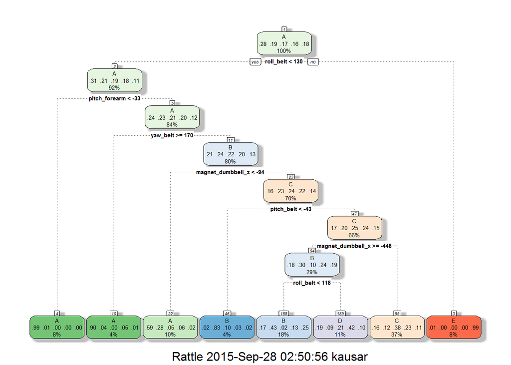

```r
fancyRpartPlot(modelCART$finalModel)
```

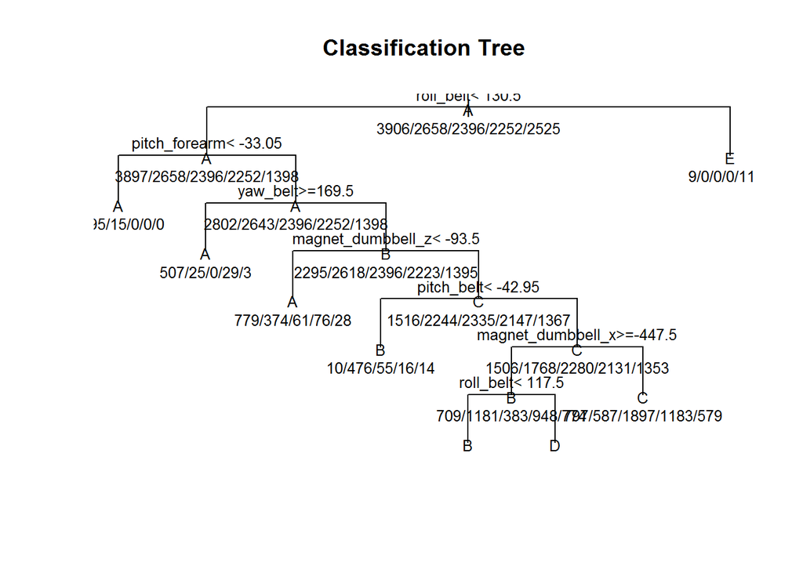

```r
plot(modelCART$finalModel, uniform=TRUE, main="Classification Tree")
text(modelCART$finalModel, use.n=TRUE, all=TRUE, cex=.8)
```

```r
predictCART <- predict(modelCART, testing)
confusionMatrix(predictCART, testing$classe)
```

```
## Confusion Matrix and Statistics
##
##           Reference
## Prediction    A    B    C    D    E
##          A 1028  179   28   47   19
##          B  158  656   43  147  242
##          C  365  248  814  509  268
##          D  118   56  141  261   49
##          E    5    0    0    0  504
##
## Overall Statistics
##
##                Accuracy : 0.5545
##                  95% CI : (0.5417, 0.5672)
##     No Information Rate : 0.2845
##     P-Value [Acc > NIR] : < 2.2e-16
##
##                   Kappa : 0.4414
##  Mcnemar's Test P-Value : < 2.2e-16
##
## Statistics by Class:
##
##                      Class: A Class: B Class: C Class: D Class: E
## Sensitivity            0.6141   0.5759   0.7934  0.27075  0.46580
## Specificity            0.9352   0.8757   0.7139  0.92603  0.99896
## Pos Pred Value         0.7902   0.5265   0.3693  0.41760  0.99018
## Neg Pred Value         0.8591   0.8959   0.9424  0.86635  0.89249
## Prevalence             0.2845   0.1935   0.1743  0.16381  0.18386
## Detection Rate         0.1747   0.1115   0.1383  0.04435  0.08564
## Detection Prevalence   0.2211   0.2117   0.3745  0.10620  0.08649
## Balanced Accuracy      0.7746   0.7258   0.7537  0.59839  0.73238
```

```r
## Random Forest
library(randomForest)
modelRF <- randomForest(classe ~ ., data=training, mtry=7, importance=TRUE)
predictRF <- predict(modelRF, testing)
confusionMatrix(predictRF, testing$classe)
```

```
## Confusion Matrix and Statistics
##
##           Reference
## Prediction    A    B    C    D    E
##          A 1673    3    0    0    0
##          B    1 1136    5    0    0
##          C    0    0 1021    7    0
##          D    0    0    0  956    3
##          E    0    0    0    1 1079
##
## Overall Statistics
##
##                Accuracy : 0.9966
##                  95% CI : (0.9948, 0.9979)
##     No Information Rate : 0.2845
##     P-Value [Acc > NIR] : < 2.2e-16
##
##                   Kappa : 0.9957
##  Mcnemar's Test P-Value : NA
##
## Statistics by Class:
##
##                      Class: A Class: B Class: C Class: D Class: E
## Sensitivity            0.9994   0.9974   0.9951   0.9917   0.9972
## Specificity            0.9993   0.9987   0.9986   0.9994   0.9998
## Pos Pred Value         0.9982   0.9947   0.9932   0.9969   0.9991
## Neg Pred Value         0.9998   0.9994   0.9990   0.9984   0.9994
## Prevalence             0.2845   0.1935   0.1743   0.1638   0.1839
## Detection Rate         0.2843   0.1930   0.1735   0.1624   0.1833
## Detection Prevalence   0.2848   0.1941   0.1747   0.1630   0.1835
## Balanced Accuracy      0.9993   0.9981   0.9968   0.9955   0.9985
```

As the random Forest model is more accurate (with an accuracy of 0.9966), it is chosen as the final model. The expected out-of-sample error is 1-0.9966 = 0.0034.